# VE of Nirsevimab

#### Date: 2024-06-16

### There are totally 3142 testing records in the analysis dataset.

### Look at the risk factors

#### Table 1 Each risk factor

| risk_factor | n_records | perc |
| --- | --- | --- |
| gestage_lessthan37wks | 423 | 13.5 |
| small_for_gestage | 313 | 10 |
| pulmonary_disease | 166 | 5.3 |
| asthma | 159 | 5.1 |
| cardiac | 156 | 5 |
| anemia | 96 | 3.1 |
| blood | 94 | 3 |
| environmental | 73 | 2.3 |
| wheezing | 32 | 1 |
| down_syndrome | 15 | 0.5 |

[output cut: 2 more lines]

#### Table 2 At least one risk factor

| risk_factor_atleastone | n | perc |
| --- | --- | --- |
| no | 2309 | 73.5 |
| yes | 833 | 26.5 |

### Table 3. Characteristic of study population (testing level)

- this is assuming that: if mAb was taken before collection date, we count it as immunized. For SSA, need to change it to: if the person took mAb more than X days before sample collection, we count it as immunized.
- we look at different pairs of case and control here (mainly to see which ones should be confounders).

#### RSV+ vs. RSV-

| Characteristic | Overall, N = 3,1421 | RSV-, N = 2,4351 | RSV+, N = 7071 | p-value2 |
| --- | --- | --- | --- | --- |
| Sex |  |  |  | 0.583 |
| Female | 1,332 (42.4%) | 1,041 (42.8%) | 291 (41.2%) |  |
| Male | 1,809 (57.6%) | 1,393 (57.2%) | 416 (58.8%) |  |
| (Missing) | 1 (0.0%) | 1 (0.0%) | 0 (0.0%) |  |
| Age at testing (months) |  |  |  | 0.039 |
| Mean (SD) | 6.9 (4.0) | 7.0 (4.1) | 6.6 (3.7) |  |
| Median (IQR) | 6.7 (3.6, 9.7) | 6.8 (3.7, 9.9) | 6.3 (3.5, 9.4) |  |
| N missing (% missing) | 0.0 (0.0%) | 0.0 (0.0%) | 0.0 (0.0%) |  |
| Age at testing |  |  |  | 0.077 |
| under 3m | 629 (20.0%) | 484 (19.9%) | 145 (20.5%) |  |
| 3-6m | 751 (23.9%) | 560 (23.0%) | 191 (27.0%) |  |
| 6-9m | 797 (25.4%) | 625 (25.7%) | 172 (24.3%) |  |
| 9-12m | 579 (18.4%) | 450 (18.5%) | 129 (18.2%) |  |
| above 1 yo | 386 (12.3%) | 316 (13.0%) | 70 (9.9%) |  |
| Time tested |  |  |  | <0.001 |
| Oct-Nov | 826 (26.3%) | 514 (21.1%) | 312 (44.1%) |  |
| Dec-Jan | 1,270 (40.4%) | 920 (37.8%) | 350 (49.5%) |  |
| Feb-Mar | 801 (25.5%) | 761 (31.3%) | 40 (5.7%) |  |
| April and after | 245 (7.8%) | 240 (9.9%) | 5 (0.7%) |  |
| Race and ethnicity |  |  |  | 0.051 |
| Hispanic | 1,340 (42.6%) | 1,047 (43.0%) | 293 (41.4%) |  |
| White non-Hispanic | 835 (26.6%) | 626 (25.7%) | 209 (29.6%) |  |
| Black non-Hispanic | 548 (17.4%) | 431 (17.7%) | 117 (16.5%) |  |
| Other non-Hispanic3 | 169 (5.4%) | 143 (5.9%) | 26 (3.7%) |  |
| unknown | 250 (8.0%) | 188 (7.7%) | 62 (8.8%) |  |
| Birth weight |  |  |  | 0.026 |
| Mean (SD) | 3,133.5 (690.4) | 3,117.0 (707.5) | 3,191.6 (624.0) |  |
| Median (IQR) | 3,224.2 (2,824.9, 3,563.8) | 3,204.4 (2,805.1, 3,553.6) | 3,289.2 (2,894.8, 3,581.2) |  |
| N missing (% missing) | 817.0 (26.0%) | 624.0 (25.6%) | 193.0 (27.3%) |  |
| Missing | 817.0 | 624.0 | 193.0 |  |
| Gestational age |  |  |  | 0.055 |
| 37 weeks or more | 1,927 (61.3%) | 1,492 (61.3%) | 435 (61.5%) |  |
| Less than 37 weeks | 423 (13.5%) | 345 (14.2%) | 78 (11.0%) |  |
| (Missing) | 792 (25.2%) | 598 (24.6%) | 194 (27.4%) |  |
| Pulmonary diseases | 166 (5.3%) | 135 (5.5%) | 31 (4.4%) | 0.225 |
| Cardiac diseases | 156 (5.0%) | 123 (5.1%) | 33 (4.7%) | 0.679 |
| Asthma | 159 (5.1%) | 123 (5.1%) | 36 (5.1%) | 0.965 |
| Anemia | 96 (3.1%) | 81 (3.3%) | 15 (2.1%) | 0.101 |
| Having at least one risk factor4 | 833 (26.5%) | 658 (27.0%) | 175 (24.8%) | 0.229 |
| Insurance type |  |  |  | 0.141 |
| private | 1,002 (31.9%) | 764 (31.4%) | 238 (33.7%) |  |
| public | 2,118 (67.4%) | 1,657 (68.0%) | 461 (65.2%) |  |
| uninsured | 22 (0.7%) | 14 (0.6%) | 8 (1.1%) |  |
| mAb status |  |  |  | <0.001 |
| No | 2,808 (89.4%) | 2,122 (87.1%) | 686 (97.0%) |  |
| Yes, 100mg dose | 94 (3.0%) | 88 (3.6%) | 6 (0.8%) |  |
| Yes, 50mg dose | 240 (7.6%) | 225 (9.2%) | 15 (2.1%) |  |

1n (%)  
2Fisher's exact test; Wilcoxon rank sum test; Pearson's Chi-squared test  
3Inclusing Asian, Pacific Islander, Middle Eastern or Northern American, American Indian or Native American by self-reporting.  
4Have at least one of the following conditions recorded in the infant's medical history or diagnosis records: 1) Anemia; 2) Asthma; 3) Liver diseases; 4) Immunodeficiency (e.g. transplantation history, leukemia, etc.); 5) Cardiac diseases (including congenital heart diseases diagnosed at birth or any reporting of heart conditions); 6) Pulmonary diseases; 7) Down syndrome; 8) Exposed to environmental exposures during gestation period or at young age (including chemical exposures: tobacco exposure, secondhand smoke etc., and socioeconomic factors: financial difficulties, unemployed parents, homelessness, etc.); 9) Small for gestational age (birth weight < 2,500 grams); 10) Prematurity (gestational age less than 37 weeks).

#### RSV+ hospitalized vs. RSV+ (outpatient)

- this is to compare severe cases requiring hospitalization and mild cases

| Characteristic | Overall, N = 7061 | RSV+ hospitalizations, N = 1731 | RSV+ outpatients, N = 5331 | p-value2 |
| --- | --- | --- | --- | --- |
| Sex |  |  |  | 0.374 |
| Female | 291 (41.2%) | 66 (38.2%) | 225 (42.2%) |  |
| Male | 415 (58.8%) | 107 (61.8%) | 308 (57.8%) |  |
| (Missing) | 0 (0.0%) | 0 (0.0%) | 0 (0.0%) |  |
| Age at testing (months) |  |  |  | <0.001 |
| Mean (SD) | 6.6 (3.7) | 5.7 (3.7) | 6.9 (3.7) |  |
| Median (IQR) | 6.3 (3.5, 9.3) | 4.9 (2.4, 8.2) | 6.6 (4.0, 9.6) |  |
| N missing (% missing) | 0.0 (0.0%) | 0.0 (0.0%) | 0.0 (0.0%) |  |
| Age at testing |  |  |  | 0.012 |
| under 3m | 145 (20.5%) | 50 (28.9%) | 95 (17.8%) |  |
| 3-6m | 191 (27.1%) | 47 (27.2%) | 144 (27.0%) |  |
| 6-9m | 172 (24.4%) | 41 (23.7%) | 131 (24.6%) |  |
| 9-12m | 128 (18.1%) | 23 (13.3%) | 105 (19.7%) |  |
| above 1 yo | 70 (9.9%) | 12 (6.9%) | 58 (10.9%) |  |
| Time tested |  |  |  | 0.264 |
| Oct-Nov | 312 (44.2%) | 80 (46.2%) | 232 (43.5%) |  |
| Dec-Jan | 349 (49.4%) | 81 (46.8%) | 268 (50.3%) |  |
| Feb-Mar | 40 (5.7%) | 9 (5.2%) | 31 (5.8%) |  |
| April and after | 5 (0.7%) | 3 (1.7%) | 2 (0.4%) |  |
| Race and ethnicity |  |  |  | 0.435 |
| Hispanic | 292 (41.4%) | 79 (45.7%) | 213 (40.0%) |  |
| White non-Hispanic | 209 (29.6%) | 51 (29.5%) | 158 (29.6%) |  |
| Black non-Hispanic | 117 (16.6%) | 28 (16.2%) | 89 (16.7%) |  |
| Other non-Hispanic3 | 26 (3.7%) | 5 (2.9%) | 21 (3.9%) |  |
| unknown | 62 (8.8%) | 10 (5.8%) | 52 (9.8%) |  |
| Birth weight |  |  |  | 0.679 |
| Mean (SD) | 3,191.3 (624.6) | 3,203.2 (683.0) | 3,187.5 (605.8) |  |
| Median (IQR) | 3,284.2 (2,894.8, 3,583.6) | 3,294.1 (2,994.7, 3,538.8) | 3,274.3 (2,867.6, 3,593.5) |  |
| N missing (% missing) | 193.0 (27.3%) | 50.0 (28.9%) | 143.0 (26.8%) |  |
| Missing | 193.0 | 50.0 | 143.0 |  |
| Gestational age |  |  |  | 0.763 |
| 37 weeks or more | 434 (61.5%) | 110 (63.6%) | 324 (60.8%) |  |
| Less than 37 weeks | 78 (11.0%) | 17 (9.8%) | 61 (11.4%) |  |
| (Missing) | 194 (27.5%) | 46 (26.6%) | 148 (27.8%) |  |
| Pulmonary diseases | 31 (4.4%) | 13 (7.5%) | 18 (3.4%) | 0.021 |
| Cardiac diseases | 32 (4.5%) | 10 (5.8%) | 22 (4.1%) | 0.364 |
| Asthma | 36 (5.1%) | 14 (8.1%) | 22 (4.1%) | 0.039 |
| Anemia | 15 (2.1%) | 3 (1.7%) | 12 (2.3%) | >0.999 |
| Having at least one risk factor4 | 174 (24.6%) | 47 (27.2%) | 127 (23.8%) | 0.376 |
| Insurance type |  |  |  | 0.868 |
| private | 238 (33.7%) | 59 (34.1%) | 179 (33.6%) |  |
| public | 460 (65.2%) | 113 (65.3%) | 347 (65.1%) |  |
| uninsured | 8 (1.1%) | 1 (0.6%) | 7 (1.3%) |  |
| mAb status |  |  |  | 0.917 |
| No | 685 (97.0%) | 168 (97.1%) | 517 (97.0%) |  |
| Yes, 100mg dose | 6 (0.8%) | 1 (0.6%) | 5 (0.9%) |  |
| Yes, 50mg dose | 15 (2.1%) | 4 (2.3%) | 11 (2.1%) |  |

1n (%)  
2Fisher's exact test; Wilcoxon rank sum test; Pearson's Chi-squared test  
3Inclusing Asian, Pacific Islander, Middle Eastern or Northern American, American Indian or Native American by self-reporting.  
4Have at least one of the following conditions recorded in the infant's medical history or diagnosis records: 1) Anemia; 2) Asthma; 3) Liver diseases; 4) Immunodeficiency (e.g. transplantation history, leukemia, etc.); 5) Cardiac diseases (including congenital heart diseases diagnosed at birth or any reporting of heart conditions); 6) Pulmonary diseases; 7) Down syndrome; 8) Exposed to environmental exposures during gestation period or at young age (including chemical exposures: tobacco exposure, secondhand smoke etc., and socioeconomic factors: financial difficulties, unemployed parents, homelessness, etc.); 9) Small for gestational age (birth weight < 2,500 grams); 10) Prematurity (gestational age less than 37 weeks).

#### RSV+ hospitalized vs. RSV- (all)

- this is to compare severe cases requiring hospitalization and all RSV-

| Characteristic | Overall, N = 2,6081 | RSV+ hospitalizations, N = 1731 | RSV-, N = 2,4351 | p-value2 |
| --- | --- | --- | --- | --- |
| Sex |  |  |  | 0.314 |
| Female | 1,107 (42.4%) | 66 (38.2%) | 1,041 (42.8%) |  |
| Male | 1,500 (57.5%) | 107 (61.8%) | 1,393 (57.2%) |  |
| (Missing) | 1 (0.0%) | 0 (0.0%) | 1 (0.0%) |  |
| Age at testing (months) |  |  |  | <0.001 |
| Mean (SD) | 6.9 (4.1) | 5.7 (3.7) | 7.0 (4.1) |  |
| Median (IQR) | 6.7 (3.6, 9.8) | 4.9 (2.4, 8.2) | 6.8 (3.7, 9.9) |  |
| N missing (% missing) | 0.0 (0.0%) | 0.0 (0.0%) | 0.0 (0.0%) |  |
| Age at testing |  |  |  | 0.005 |
| under 3m | 534 (20.5%) | 50 (28.9%) | 484 (19.9%) |  |
| 3-6m | 607 (23.3%) | 47 (27.2%) | 560 (23.0%) |  |
| 6-9m | 666 (25.5%) | 41 (23.7%) | 625 (25.7%) |  |
| 9-12m | 473 (18.1%) | 23 (13.3%) | 450 (18.5%) |  |
| above 1 yo | 328 (12.6%) | 12 (6.9%) | 316 (13.0%) |  |
| Time tested |  |  |  | <0.001 |
| Oct-Nov | 594 (22.8%) | 80 (46.2%) | 514 (21.1%) |  |
| Dec-Jan | 1,001 (38.4%) | 81 (46.8%) | 920 (37.8%) |  |
| Feb-Mar | 770 (29.5%) | 9 (5.2%) | 761 (31.3%) |  |
| April and after | 243 (9.3%) | 3 (1.7%) | 240 (9.9%) |  |
| Race and ethnicity |  |  |  | 0.320 |
| Hispanic | 1,126 (43.2%) | 79 (45.7%) | 1,047 (43.0%) |  |
| White non-Hispanic | 677 (26.0%) | 51 (29.5%) | 626 (25.7%) |  |
| Black non-Hispanic | 459 (17.6%) | 28 (16.2%) | 431 (17.7%) |  |
| Other non-Hispanic3 | 148 (5.7%) | 5 (2.9%) | 143 (5.9%) |  |
| unknown | 198 (7.6%) | 10 (5.8%) | 188 (7.7%) |  |
| Birth weight |  |  |  | 0.110 |
| Mean (SD) | 3,122.5 (706.1) | 3,203.2 (683.0) | 3,117.0 (707.5) |  |
| Median (IQR) | 3,214.3 (2,815.0, 3,553.6) | 3,294.1 (2,994.7, 3,538.8) | 3,204.4 (2,805.1, 3,553.6) |  |
| N missing (% missing) | 674.0 (25.8%) | 50.0 (28.9%) | 624.0 (25.6%) |  |
| Missing | 674.0 | 50.0 | 624.0 |  |
| Gestational age |  |  |  | 0.272 |
| 37 weeks or more | 1,602 (61.4%) | 110 (63.6%) | 1,492 (61.3%) |  |
| Less than 37 weeks | 362 (13.9%) | 17 (9.8%) | 345 (14.2%) |  |
| (Missing) | 644 (24.7%) | 46 (26.6%) | 598 (24.6%) |  |
| Pulmonary diseases | 148 (5.7%) | 13 (7.5%) | 135 (5.5%) | 0.279 |
| Cardiac diseases | 133 (5.1%) | 10 (5.8%) | 123 (5.1%) | 0.674 |
| Asthma | 137 (5.3%) | 14 (8.1%) | 123 (5.1%) | 0.083 |
| Anemia | 84 (3.2%) | 3 (1.7%) | 81 (3.3%) | 0.252 |
| Having at least one risk factor4 | 705 (27.0%) | 47 (27.2%) | 658 (27.0%) | 0.967 |
| Insurance type |  |  |  | 0.611 |
| private | 823 (31.6%) | 59 (34.1%) | 764 (31.4%) |  |
| public | 1,770 (67.9%) | 113 (65.3%) | 1,657 (68.0%) |  |
| uninsured | 15 (0.6%) | 1 (0.6%) | 14 (0.6%) |  |
| mAb status |  |  |  | <0.001 |
| No | 2,290 (87.8%) | 168 (97.1%) | 2,122 (87.1%) |  |
| Yes, 100mg dose | 89 (3.4%) | 1 (0.6%) | 88 (3.6%) |  |
| Yes, 50mg dose | 229 (8.8%) | 4 (2.3%) | 225 (9.2%) |  |

1n (%)  
2Fisher's exact test; Wilcoxon rank sum test; Pearson's Chi-squared test  
3Inclusing Asian, Pacific Islander, Middle Eastern or Northern American, American Indian or Native American by self-reporting.  
4Have at least one of the following conditions recorded in the infant's medical history or diagnosis records: 1) Anemia; 2) Asthma; 3) Liver diseases; 4) Immunodeficiency (e.g. transplantation history, leukemia, etc.); 5) Cardiac diseases (including congenital heart diseases diagnosed at birth or any reporting of heart conditions); 6) Pulmonary diseases; 7) Down syndrome; 8) Exposed to environmental exposures during gestation period or at young age (including chemical exposures: tobacco exposure, secondhand smoke etc., and socioeconomic factors: financial difficulties, unemployed parents, homelessness, etc.); 9) Small for gestational age (birth weight < 2,500 grams); 10) Prematurity (gestational age less than 37 weeks).

#### Inpatient vs. outpatient

- this is to compare inpatient and outpatient records

| Characteristic | Overall, N = 3,0981 | Inpatient, N = 5521 | Outpatient, N = 2,5461 | p-value2 |
| --- | --- | --- | --- | --- |
| positive_rsv |  |  |  | <0.001 |
| RSV- | 2,392 (77.2%) | 379 (68.7%) | 2,013 (79.1%) |  |
| RSV+ | 706 (22.8%) | 173 (31.3%) | 533 (20.9%) |  |
| Sex |  |  |  | 0.594 |
| Female | 1,309 (42.3%) | 226 (40.9%) | 1,083 (42.5%) |  |
| Male | 1,788 (57.7%) | 326 (59.1%) | 1,462 (57.4%) |  |
| (Missing) | 1 (0.0%) | 0 (0.0%) | 1 (0.0%) |  |
| Age at testing (months) |  |  |  | <0.001 |
| Mean (SD) | 7.0 (4.0) | 6.0 (4.4) | 7.2 (3.9) |  |
| Median (IQR) | 6.8 (3.7, 9.8) | 5.8 (1.8, 9.1) | 7.0 (4.1, 9.9) |  |
| N missing (% missing) | 0.0 (0.0%) | 0.0 (0.0%) | 0.0 (0.0%) |  |
| Age at testing |  |  |  | <0.001 |
| under 3m | 599 (19.3%) | 178 (32.2%) | 421 (16.5%) |  |
| 3-6m | 741 (23.9%) | 109 (19.7%) | 632 (24.8%) |  |
| 6-9m | 796 (25.7%) | 124 (22.5%) | 672 (26.4%) |  |
| 9-12m | 577 (18.6%) | 79 (14.3%) | 498 (19.6%) |  |
| above 1 yo | 385 (12.4%) | 62 (11.2%) | 323 (12.7%) |  |
| Time tested |  |  |  | 0.018 |
| Oct-Nov | 814 (26.3%) | 164 (29.7%) | 650 (25.5%) |  |
| Dec-Jan | 1,253 (40.4%) | 204 (37.0%) | 1,049 (41.2%) |  |
| Feb-Mar | 786 (25.4%) | 152 (27.5%) | 634 (24.9%) |  |
| April and after | 245 (7.9%) | 32 (5.8%) | 213 (8.4%) |  |
| Race and ethnicity |  |  |  | 0.082 |
| Hispanic | 1,323 (42.7%) | 233 (42.2%) | 1,090 (42.8%) |  |
| White non-Hispanic | 824 (26.6%) | 164 (29.7%) | 660 (25.9%) |  |
| Black non-Hispanic | 532 (17.2%) | 95 (17.2%) | 437 (17.2%) |  |
| Other non-Hispanic3 | 169 (5.5%) | 30 (5.4%) | 139 (5.5%) |  |
| unknown | 250 (8.1%) | 30 (5.4%) | 220 (8.6%) |  |
| Birth weight |  |  |  | 0.103 |
| Mean (SD) | 3,162.1 (649.9) | 3,077.5 (792.7) | 3,180.3 (613.8) |  |
| Median (IQR) | 3,234.4 (2,855.0, 3,565.8) | 3,204.4 (2,737.7, 3,543.7) | 3,249.4 (2,875.0, 3,573.7) |  |
| N missing (% missing) | 817.0 (26.4%) | 150.0 (27.2%) | 667.0 (26.2%) |  |
| Missing | 817.0 | 150.0 | 667.0 |  |
| Gestational age |  |  |  | <0.001 |
| 37 weeks or more | 1,913 (61.7%) | 318 (57.6%) | 1,595 (62.6%) |  |
| Less than 37 weeks | 393 (12.7%) | 103 (18.7%) | 290 (11.4%) |  |
| (Missing) | 792 (25.6%) | 131 (23.7%) | 661 (26.0%) |  |
| Pulmonary diseases | 144 (4.6%) | 60 (10.9%) | 84 (3.3%) | <0.001 |
| Cardiac diseases | 130 (4.2%) | 50 (9.1%) | 80 (3.1%) | <0.001 |
| Asthma | 159 (5.1%) | 57 (10.3%) | 102 (4.0%) | <0.001 |
| Anemia | 77 (2.5%) | 21 (3.8%) | 56 (2.2%) | 0.028 |
| Having at least one risk factor4 | 789 (25.5%) | 208 (37.7%) | 581 (22.8%) | <0.001 |
| Insurance type |  |  |  | 0.065 |
| private | 988 (31.9%) | 194 (35.1%) | 794 (31.2%) |  |
| public | 2,088 (67.4%) | 357 (64.7%) | 1,731 (68.0%) |  |
| uninsured | 22 (0.7%) | 1 (0.2%) | 21 (0.8%) |  |
| mAb status |  |  |  | 0.005 |
| No | 2,773 (89.5%) | 474 (85.9%) | 2,299 (90.3%) |  |
| Yes, 100mg dose | 94 (3.0%) | 19 (3.4%) | 75 (2.9%) |  |
| Yes, 50mg dose | 231 (7.5%) | 59 (10.7%) | 172 (6.8%) |  |

1n (%)  
2Pearson's Chi-squared test; Fisher's exact test; Wilcoxon rank sum test  
3Inclusing Asian, Pacific Islander, Middle Eastern or Northern American, American Indian or Native American by self-reporting.  
4Have at least one of the following conditions recorded in the infant's medical history or diagnosis records: 1) Anemia; 2) Asthma; 3) Liver diseases; 4) Immunodeficiency (e.g. transplantation history, leukemia, etc.); 5) Cardiac diseases (including congenital heart diseases diagnosed at birth or any reporting of heart conditions); 6) Pulmonary diseases; 7) Down syndrome; 8) Exposed to environmental exposures during gestation period or at young age (including chemical exposures: tobacco exposure, secondhand smoke etc., and socioeconomic factors: financial difficulties, unemployed parents, homelessness, etc.); 9) Small for gestational age (birth weight < 2,500 grams); 10) Prematurity (gestational age less than 37 weeks).

#### LRTI vs. no LRTI

- this is to compare those with symptoms of LRTI and those without LRTI symptoms

| Characteristic | Overall, N = 3,1421 | LRTI, N = 7561 | no LRTI, N = 2,3861 | p-value2 |
| --- | --- | --- | --- | --- |
| positive_rsv |  |  |  | <0.001 |
| RSV- | 2,435 (77.5%) | 382 (50.5%) | 2,053 (86.0%) |  |
| RSV+ | 707 (22.5%) | 374 (49.5%) | 333 (14.0%) |  |
| Sex |  |  |  | 0.015 |
| Female | 1,332 (42.4%) | 295 (39.0%) | 1,037 (43.5%) |  |
| Male | 1,809 (57.6%) | 460 (60.8%) | 1,349 (56.5%) |  |
| (Missing) | 1 (0.0%) | 1 (0.1%) | 0 (0.0%) |  |
| Age at testing (months) |  |  |  | 0.818 |
| Mean (SD) | 6.9 (4.0) | 6.9 (3.8) | 6.9 (4.1) |  |
| Median (IQR) | 6.7 (3.6, 9.7) | 6.5 (4.1, 9.5) | 6.8 (3.5, 9.8) |  |
| N missing (% missing) | 0.0 (0.0%) | 0.0 (0.0%) | 0.0 (0.0%) |  |
| Age at testing |  |  |  | <0.001 |
| under 3m | 629 (20.0%) | 121 (16.0%) | 508 (21.3%) |  |
| 3-6m | 751 (23.9%) | 217 (28.7%) | 534 (22.4%) |  |
| 6-9m | 797 (25.4%) | 195 (25.8%) | 602 (25.2%) |  |
| 9-12m | 579 (18.4%) | 140 (18.5%) | 439 (18.4%) |  |
| above 1 yo | 386 (12.3%) | 83 (11.0%) | 303 (12.7%) |  |
| Time tested |  |  |  | <0.001 |
| Oct-Nov | 826 (26.3%) | 241 (31.9%) | 585 (24.5%) |  |
| Dec-Jan | 1,270 (40.4%) | 310 (41.0%) | 960 (40.2%) |  |
| Feb-Mar | 801 (25.5%) | 162 (21.4%) | 639 (26.8%) |  |
| April and after | 245 (7.8%) | 43 (5.7%) | 202 (8.5%) |  |
| Race and ethnicity |  |  |  | 0.020 |
| Hispanic | 1,340 (42.6%) | 314 (41.5%) | 1,026 (43.0%) |  |
| White non-Hispanic | 835 (26.6%) | 234 (31.0%) | 601 (25.2%) |  |
| Black non-Hispanic | 548 (17.4%) | 120 (15.9%) | 428 (17.9%) |  |
| Other non-Hispanic3 | 169 (5.4%) | 32 (4.2%) | 137 (5.7%) |  |
| unknown | 250 (8.0%) | 56 (7.4%) | 194 (8.1%) |  |
| Birth weight |  |  |  | 0.044 |
| Mean (SD) | 3,133.5 (690.4) | 3,085.8 (710.2) | 3,148.1 (683.8) |  |
| Median (IQR) | 3,224.2 (2,824.9, 3,563.8) | 3,179.4 (2,775.1, 3,538.6) | 3,244.3 (2,865.1, 3,573.7) |  |
| N missing (% missing) | 817.0 (26.0%) | 211.0 (27.9%) | 606.0 (25.4%) |  |
| Missing | 817.0 | 211.0 | 606.0 |  |
| Gestational age |  |  |  | 0.005 |
| 37 weeks or more | 1,927 (61.3%) | 436 (57.7%) | 1,491 (62.5%) |  |
| Less than 37 weeks | 423 (13.5%) | 127 (16.8%) | 296 (12.4%) |  |
| (Missing) | 792 (25.2%) | 193 (25.5%) | 599 (25.1%) |  |
| Pulmonary diseases | 166 (5.3%) | 83 (11.0%) | 83 (3.5%) | <0.001 |
| Cardiac diseases | 156 (5.0%) | 55 (7.3%) | 101 (4.2%) | <0.001 |
| Asthma | 159 (5.1%) | 79 (10.4%) | 80 (3.4%) | <0.001 |
| Anemia | 96 (3.1%) | 20 (2.6%) | 76 (3.2%) | 0.452 |
| Having at least one risk factor4 | 833 (26.5%) | 268 (35.4%) | 565 (23.7%) | <0.001 |
| Insurance type |  |  |  | 0.864 |
| private | 1,002 (31.9%) | 247 (32.7%) | 755 (31.6%) |  |
| public | 2,118 (67.4%) | 504 (66.7%) | 1,614 (67.6%) |  |
| uninsured | 22 (0.7%) | 5 (0.7%) | 17 (0.7%) |  |
| mAb status |  |  |  | 0.214 |
| No | 2,808 (89.4%) | 688 (91.0%) | 2,120 (88.9%) |  |
| Yes, 100mg dose | 94 (3.0%) | 21 (2.8%) | 73 (3.1%) |  |
| Yes, 50mg dose | 240 (7.6%) | 47 (6.2%) | 193 (8.1%) |  |

1n (%)  
2Pearson's Chi-squared test; Fisher's exact test; Wilcoxon rank sum test  
3Inclusing Asian, Pacific Islander, Middle Eastern or Northern American, American Indian or Native American by self-reporting.  
4Have at least one of the following conditions recorded in the infant's medical history or diagnosis records: 1) Anemia; 2) Asthma; 3) Liver diseases; 4) Immunodeficiency (e.g. transplantation history, leukemia, etc.); 5) Cardiac diseases (including congenital heart diseases diagnosed at birth or any reporting of heart conditions); 6) Pulmonary diseases; 7) Down syndrome; 8) Exposed to environmental exposures during gestation period or at young age (including chemical exposures: tobacco exposure, secondhand smoke etc., and socioeconomic factors: financial difficulties, unemployed parents, homelessness, etc.); 9) Small for gestational age (birth weight < 2,500 grams); 10) Prematurity (gestational age less than 37 weeks).

### Clinical outcomes

#### Table 8.

| Characteristic | Overall, N = 3,1421 | RSV-, N = 2,4351 | RSV+, N = 7071 |
| --- | --- | --- | --- |
| mAb status |  |  |  |
| 100mg dose | 94 (3.0%) | 88 (3.6%) | 6 (0.8%) |
| 50mg dose | 240 (7.6%) | 225 (9.2%) | 15 (2.1%) |
| Not vaccinated | 2,808 (89.4%) | 2,122 (87.1%) | 686 (97.0%) |
| Hospital admission | 552 (17.6%) | 379 (15.6%) | 173 (24.5%) |
| Duration of hospitalization (days) |  |  |  |
| Median (IQR) | 1.0 (1.0, 3.0) | 1.0 (1.0, 3.0) | 1.0 (1.0, 2.0) |
| N missing (% missing) | 2,512.0 (79.9%) | 1,985.0 (81.5%) | 527.0 (74.5%) |
| Missing | 2,512.0 | 1,985.0 | 527.0 |
| ICU admission | 97 (3.1%) | 74 (3.0%) | 23 (3.3%) |
| Duration of ICU admission (days) |  |  |  |
| Median (IQR) | 4.0 (1.7, 15.7) | 5.1 (1.5, 19.8) | 3.0 (1.8, 7.2) |
| N missing (% missing) | 3,002.0 (95.5%) | 2,319.0 (95.2%) | 683.0 (96.6%) |
| Missing | 3,002.0 | 2,319.0 | 683.0 |
| Required highflow oxygen support | 424 (13.5%) | 274 (11.3%) | 150 (21.2%) |
| Distress in URT | 1,367 (43.5%) | 1,129 (46.4%) | 238 (33.7%) |
| Distress in LRT | 756 (24.1%) | 382 (15.7%) | 374 (52.9%) |
| Fever (> 38°C/100.4°F) | 1,443 (45.9%) | 1,189 (48.8%) | 254 (35.9%) |
| Cough | 462 (14.7%) | 362 (14.9%) | 100 (14.1%) |
| Wheezing | 38 (1.2%) | 29 (1.2%) | 9 (1.3%) |
| Breathing difficulties | 48 (1.5%) | 45 (1.8%) | 3 (0.4%) |
| Bronchiolitis | 663 (21.1%) | 304 (12.5%) | 359 (50.8%) |
| Sepsis | 27 (0.9%) | 25 (1.0%) | 2 (0.3%) |

1n (%)

```r
# For VE against infection,
# only adjusting for those that has significant difference comparing RSV+ and RSV- records
confounders_infection <- c(
  "age_at_test_in_months_cat_2", # 3-month interval
  "month_when_tested_cat",
  "birth_weight"
)

# For VE against severity
# only adjusting for those that has significant difference comparing RSV+ hospitalization and RSV+ outpatient
confounders_severity <- c(
  "age_at_test_in_months_cat_2", # 3-month interval
  "month_when_tested_cat",
  "risk_factor_pulmonary",
  "risk_factor_asthma"
)

# For VE against severity (2)
# only adjusting for those that has significant difference comparing RSV+ hospitalization and RSV-
confounders_severity_2 <- c(
  "age_at_test_in_months_cat_2", # 3-month interval
  "month_when_tested_cat"
)

# For VE against hospitalization
# only adjusting for those that has significant difference comparing inpatient and outpatient
confounders_encounter <- c(
  "age_at_test_in_months_cat_2", # 3-month interval
  "month_when_tested_cat",
  "risk_factor_gestagelessthan37wks",
  "risk_factor_pulmonary",
  "risk_factor_cardiac",
  "risk_factor_asthma",
  "risk_factor_anemia",
  "risk_factor_atleastone"

)


confounders_LRTI <- c(
  "Sex",
  "age_at_test_in_months_cat_2", # 3-month interval
  "month_when_tested_cat",
  "race_ethnicity",
  "birth_weight",
  "risk_factor_gestagelessthan37wks",
  "risk_factor_pulmonary",
  "risk_factor_cardiac",
  "risk_factor_asthma",
  "risk_factor_anemia",
  "risk_factor_atleastone"
)
```

### Table 9. Effectiveness of Nirsevimab

##### Here, I pooled all the cases and controls together, to estimate the VE for different pairs of case and control definitions.

- Columns n_overall, n_cases, n_controls are numbers of individuals were sample size used in the analysis.
  - The sample size outside the parenthesis is the sample size that contributes to estimates of **unadjusted** effectiveness in the logistic regression models.
  - The sample size inside the parenthesis is the sample size that effectively contributes to estimates of **adjusted** effectiveness in the logistic regression models.

#### Table 9.

| case | control | n_cases_mab | n_cases_nomab | n_controls_mab | n_controls_nomab | ve_unadj | ve_adj |
| --- | --- | --- | --- | --- | --- | --- | --- |
| RSV+ (inpatient) | RSV- (inpatient) | 5 (5) | 168 (118) | 73 (62) | 306 (217) | 87.5 (71.4-95.7) | 82.4 (55.1-94.3) |
| RSV+ (outpatient) | RSV- (outpatient) | 16 (15) | 517 (375) | 231 (215) | 1782 (1274) | 76.1 (61.3-86.3) | 62.4 (35.6-79.5) |
| RSV+ (all) | RSV- (all) | 21 (20) | 686 (494) | 313 (286) | 2122 (1525) | 79.2 (68.3-87.2) | 66.2 (46-79.9) |
| RSV+ hospitalizations | RSV- (all) | 5 (5) | 168 (168) | 313 (313) | 2122 (2122) | 79.8 (55.4-92.9) | 74.6 (42.4-91.2) |
| severe RSV+ hospitalizations | RSV- (all) | 4 (4) | 96 (96) | 313 (313) | 2122 (2122) | 71.8 (31.9-91.4) | 59.1 (-2.4-87.8) |
| RSV+ ICU admission | RSV- (all) | 1 (1) | 22 (22) | 313 (313) | 2122 (2122) | 69.2 (-47.4-98.3) | 50 (-164.9-97.3) |
| RSV+ LRTI hospitalizations | RSV- (all) | 5 (5) | 151 (151) | 313 (313) | 2122 (2122) | 77.6 (50.3-92.1) | 70.8 (33.5-89.9) |
| severe RSV+ LRTI hospitalizations | RSV- (all) | 4 (4) | 94 (94) | 313 (313) | 2122 (2122) | 71.2 (30.4-91.2) | 57.9 (-5.4-87.5) |
| RSV+ LRTI | RSV- (all) | 10 (10) | 364 (364) | 313 (313) | 2122 (2122) | 81.4 (66.6-90.8) | 73.5 (51.4-87.2) |
| severe RSV+ LRTI | RSV- (all) | 4 (4) | 125 (125) | 313 (313) | 2122 (2122) | 78.3 (48-93.4) | 70.5 (27.1-91.1) |

[output cut: 5 more lines]

#### Figure 1.

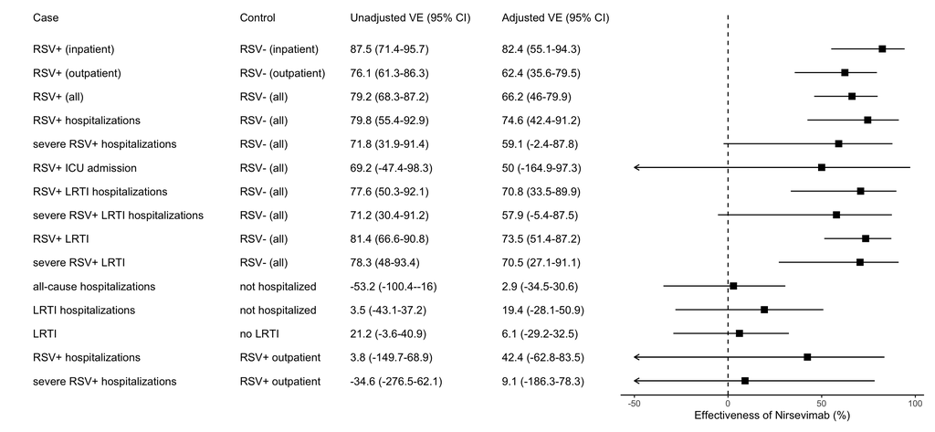

#### Figure 2. (with n_records)

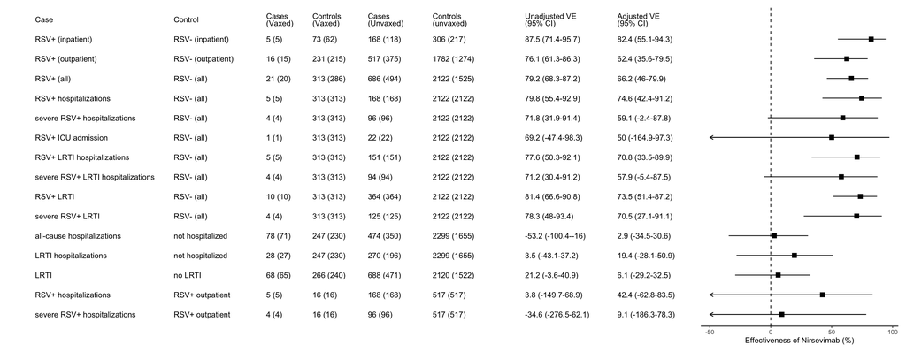

### Look at how VE of mAb changes over time

#### Table 10 2 months interval

Why the unadjusted and adjusted are reversed?

| case_control | strata | n.cases | n.controls | VE.unadjusted | VE.adjusted |
| --- | --- | --- | --- | --- | --- |
| RSV+ vs. RSV- | not immunized | 686 (494) | 2122 (1525) | REF | REF |
| RSV+ vs. RSV- | immunized 0-2 months ago | 15 (15) | 154 (145) | 69.9 (50.2-83.1) | 66.2 (42.2-81.5) |
| RSV+ vs. RSV- | immuniaed 2-4 months ago | 5 (4) | 109 (96) | 85.8 (68.5-95) | 68.7 (21.3-90.7) |
| RSV+ vs. RSV- | immunized 4 months + ago | 1 (1) | 50 (45) | 93.8 (71.7-99.7) | 51.8 (-134.6-97.3) |
| RSV+ hospitalization vs. RSV- | not immunized | 168 (168) | 2122 (2122) | REF | REF |
| RSV+ hospitalization vs. RSV- | immunized 0-2 months ago | 3 (3) | 154 (154) | 75.4 (34.2-94) | 80 (45.4-95.2) |
| RSV+ hospitalization vs. RSV- | immuniaed 2-4 months ago | 1 (1) | 109 (109) | 88.4 (47.7-99.3) | 75.5 (-15.3-98.6) |
| RSV+ hospitalization vs. RSV- | immunized 4 months + ago | 1 (1) | 50 (50) | 74.7 (-16.2-98.6) | -55.6 (-755-91.7) |
| RSV+ LRTI vs. RSV- | not immunized | 364 (364) | 2122 (2122) | REF | REF |
| RSV+ LRTI vs. RSV- | immunized 0-2 months ago | 6 (6) | 154 (154) | 77.3 (52.6-91.1) | 78.6 (54.4-91.7) |

[output cut: 6 more lines]

#### Table 11 3 months interval

| case_control | strata | n.cases | n.controls | VE.unadjusted | VE.adjusted |
| --- | --- | --- | --- | --- | --- |
| RSV+ vs. RSV- | not immunized | 686 (494) | 2122 (1525) | REF | REF |
| RSV+ vs. RSV- | immunized 0-3 months ago | 17 (17) | 211 (196) | 75.1 (60.1-85.5) | 68.3 (47.6-82) |
| RSV+ vs. RSV- | immuniaed 3-6 months ago | 4 (3) | 102 (90) | 87.9 (70.9-96.3) | 47.9 (-50.8-87.7) |
| RSV+ hospitalizations vs. RSV- | not immunized | 168 (168) | 2122 (2122) | REF | REF |
| RSV+ hospitalizations vs. RSV- | immunized 0-3 months ago | 3 (3) | 211 (211) | 82 (52.2-95.6) | 83.4 (54.7-96) |
| RSV+ hospitalizations vs. RSV- | immuniaed 3-6 months ago | 2 (2) | 102 (102) | 75.2 (21-95.9) | -13.1 (-313.8-82.5) |
| RSV+ LRTI vs. RSV- | not immunized | 364 (364) | 2122 (2122) | REF | REF |
| RSV+ LRTI vs. RSV- | immunized 0-3 months ago | 8 (8) | 211 (211) | 77.9 (57.7-90.1) | 76.4 (53.9-89.5) |
| RSV+ LRTI vs. RSV- | immuniaed 3-6 months ago | 2 (2) | 102 (102) | 88.6 (63.8-98.1) | 50.1 (-71.6-92.1) |
| RSV+ LRTI hospitalizations vs. RSV- | not immunized | 151 (151) | 2122 (2122) | REF | REF |

[output cut: 2 more lines]

### Look at whether dosage has an influence on VE.

#### Table 12 Compare infants who took 100mg and 50mg dosage

| Characteristic | Overall, N = 3341 | 100mg, N = 941 | 50mg, N = 2401 | p-value2 |
| --- | --- | --- | --- | --- |
| Sex |  |  |  | 0.140 |
| Female | 139 (41.6%) | 33 (35.1%) | 106 (44.2%) |  |
| Male | 195 (58.4%) | 61 (64.9%) | 134 (55.8%) |  |
| (Missing) | 0 (0.0%) | 0 (0.0%) | 0 (0.0%) |  |
| Age at testing (months) |  |  |  | <0.001 |
| Mean (SD) | 4.2 (3.0) | 7.4 (2.6) | 2.9 (2.0) |  |
| Median (IQR) | 3.4 (1.8, 5.9) | 7.2 (5.6, 8.8) | 2.4 (1.5, 3.8) |  |
| N missing (% missing) | 0.0 (0.0%) | 0.0 (0.0%) | 0.0 (0.0%) |  |
| Age at testing |  |  |  | <0.001 |
| under 3m | 144 (43.1%) | 2 (2.1%) | 142 (59.2%) |  |
| 3-6m | 108 (32.3%) | 28 (29.8%) | 80 (33.3%) |  |
| 6-9m | 57 (17.1%) | 42 (44.7%) | 15 (6.3%) |  |
| 9-12m | 19 (5.7%) | 17 (18.1%) | 2 (0.8%) |  |
| above 1 yo | 6 (1.8%) | 5 (5.3%) | 1 (0.4%) |  |
| Time tested |  |  |  | 0.011 |
| Oct-Nov | 25 (7.5%) | 14 (14.9%) | 11 (4.6%) |  |
| Dec-Jan | 118 (35.3%) | 34 (36.2%) | 84 (35.0%) |  |
| Feb-Mar | 145 (43.4%) | 35 (37.2%) | 110 (45.8%) |  |
| April and after | 46 (13.8%) | 11 (11.7%) | 35 (14.6%) |  |
| Race and ethnicity |  |  |  | 0.003 |
| Hispanic | 137 (41.0%) | 33 (35.1%) | 104 (43.3%) |  |
| White non-Hispanic | 70 (21.0%) | 15 (16.0%) | 55 (22.9%) |  |
| Black non-Hispanic | 89 (26.6%) | 26 (27.7%) | 63 (26.3%) |  |
| Other non-Hispanic3 | 24 (7.2%) | 15 (16.0%) | 9 (3.8%) |  |
| unknown | 14 (4.2%) | 5 (5.3%) | 9 (3.8%) |  |
| Birth weight |  |  |  | 0.832 |
| Mean (SD) | 2,920.8 (846.3) | 2,886.7 (1,021.7) | 2,934.6 (766.5) |  |
| Median (IQR) | 3,084.6 (2,551.7, 3,455.1) | 3,114.4 (2,525.6, 3,496.4) | 3,044.7 (2,575.6, 3,443.8) |  |
| N missing (% missing) | 28.0 (8.4%) | 6.0 (6.4%) | 22.0 (9.2%) |  |
| Missing | 28.0 | 6.0 | 22.0 |  |
| Gestational age |  |  |  | 0.052 |
| 37 weeks or more | 217 (65.0%) | 61 (64.9%) | 156 (65.0%) |  |
| Less than 37 weeks | 93 (27.8%) | 31 (33.0%) | 62 (25.8%) |  |
| (Missing) | 24 (7.2%) | 2 (2.1%) | 22 (9.2%) |  |
| Pulmonary diseases | 18 (5.4%) | 10 (10.6%) | 8 (3.3%) | 0.008 |
| Cardiac diseases | 34 (10.2%) | 7 (7.4%) | 27 (11.3%) | 0.301 |
| Asthma | 9 (2.7%) | 9 (9.6%) | 0 (0.0%) | <0.001 |
| Anemia | 11 (3.3%) | 6 (6.4%) | 5 (2.1%) | 0.081 |
| Having at least one risk factor4 | 141 (42.2%) | 53 (56.4%) | 88 (36.7%) | 0.001 |
| Insurance type |  |  |  | 0.479 |
| private | 81 (24.3%) | 20 (21.3%) | 61 (25.4%) |  |
| public | 253 (75.7%) | 74 (78.7%) | 179 (74.6%) |  |
| uninsured | 0 (0.0%) | 0 (0.0%) | 0 (0.0%) |  |
| symp_LRT_distress | 68 (100.0%) | 21 (100.0%) | 47 (100.0%) |  |
| Missing | 266 | 73 | 193 |  |

1n (%)  
2Fisher's exact test; Wilcoxon rank sum test; Pearson's Chi-squared test  
3Inclusing Asian, Pacific Islander, Middle Eastern or Northern American, American Indian or Native American by self-reporting.  
4Have at least one of the following conditions recorded in the infant's medical history or diagnosis records: 1) Anemia; 2) Asthma; 3) Liver diseases; 4) Immunodeficiency (e.g. transplantation history, leukemia, etc.); 5) Cardiac diseases (including congenital heart diseases diagnosed at birth or any reporting of heart conditions); 6) Pulmonary diseases; 7) Down syndrome; 8) Exposed to environmental exposures during gestation period or at young age (including chemical exposures: tobacco exposure, secondhand smoke etc., and socioeconomic factors: financial difficulties, unemployed parents, homelessness, etc.); 9) Small for gestational age (birth weight < 2,500 grams); 10) Prematurity (gestational age less than 37 weeks).

#### Table 13 VE by dosage (100mg vs. not vaccinated)

| case | control | n_cases_mab | n_cases_nomab | n_controls_mab | n_controls_nomab | ve_unadj | ve_adj |
| --- | --- | --- | --- | --- | --- | --- | --- |
| RSV+ (inpatient) | RSV- (inpatient) | 1 (1) | 168 (118) | 18 (15) | 306 (217) | 89.9 (50.3-99.4) | 89 (36.1-99.4) |
| RSV+ (outpatient) | RSV- (outpatient) | 5 (5) | 517 (375) | 70 (67) | 1782 (1274) | 75.4 (44.5-91.4) | 67.1 (22.8-88.8) |
| RSV+ (all) | RSV- (all) | 6 (6) | 686 (494) | 88 (82) | 2122 (1525) | 78.9 (55.5-91.8) | 71.4 (37.5-89.2) |
| RSV+ hospitalizations | RSV- (all) | 1 (1) | 168 (168) | 88 (88) | 2122 (2122) | 85.6 (34.9-99.2) | 80.7 (10.1-98.9) |
| severe RSV+ hospitalizations | RSV- (all) | 1 (1) | 96 (96) | 88 (88) | 2122 (2122) | 74.9 (-14.8-98.6) | 64.7 (-66.8-98) |
| RSV+ LRTI hospitalizations | RSV- (all) | 1 (1) | 151 (151) | 88 (88) | 2122 (2122) | 84 (27.5-99.1) | 79 (2.1-98.8) |
| severe RSV+ LRTI hospitalizations | RSV- (all) | 1 (1) | 94 (94) | 88 (88) | 2122 (2122) | 74.3 (-17.2-98.6) | 64.1 (-69.8-98) |
| RSV+ LRTI | RSV- (all) | 3 (3) | 364 (364) | 88 (88) | 2122 (2122) | 80.1 (46.7-95.1) | 75.8 (33-94.2) |
| severe RSV+ LRTI | RSV- (all) | 1 (1) | 125 (125) | 88 (88) | 2122 (2122) | 80.7 (12.2-98.9) | 74.2 (-21.2-98.6) |
| all-cause hospitalizations | not hospitalized | 19 (19) | 474 (350) | 75 (73) | 2299 (1655) | -22.9 (-100.9-28.4) | -21 (-106.7-32.2) |

[output cut: 4 more lines]

#### Table 14 VE by dosage (50mg vs. not vaccinated)

| case | control | n_cases_mab | n_cases_nomab | n_controls_mab | n_controls_nomab | ve_unadj | ve_adj |
| --- | --- | --- | --- | --- | --- | --- | --- |
| RSV+ (inpatient) | RSV- (inpatient) | 4 (4) | 168 (118) | 55 (47) | 306 (217) | 86.8 (67-96) | 81.1 (46.7-94.7) |
| RSV+ (outpatient) | RSV- (outpatient) | 11 (10) | 517 (375) | 161 (148) | 1782 (1274) | 76.5 (58.3-88) | 59.4 (21.3-81) |
| RSV+ (all) | RSV- (all) | 15 (14) | 686 (494) | 225 (204) | 2122 (1525) | 79.4 (66.2-88.4) | 63.4 (36-80.5) |
| RSV+ hospitalizations | RSV- (all) | 4 (4) | 168 (168) | 225 (225) | 2122 (2122) | 77.5 (46.3-93.1) | 72.4 (31.1-91.7) |
| severe RSV+ hospitalizations | RSV- (all) | 3 (3) | 96 (96) | 225 (225) | 2122 (2122) | 70.5 (20.8-92.8) | 56.7 (-24.3-89.8) |
| RSV+ LRTI hospitalizations | RSV- (all) | 4 (4) | 151 (151) | 225 (225) | 2122 (2122) | 75 (40.2-92.4) | 67.5 (18.5-90.3) |
| severe RSV+ LRTI hospitalizations | RSV- (all) | 3 (3) | 94 (94) | 225 (225) | 2122 (2122) | 69.9 (19.1-92.6) | 55.3 (-28.7-89.4) |
| RSV+ LRTI | RSV- (all) | 7 (7) | 364 (364) | 225 (225) | 2122 (2122) | 81.9 (64.1-92.3) | 72.5 (43.6-88.6) |
| severe RSV+ LRTI | RSV- (all) | 3 (3) | 125 (125) | 225 (225) | 2122 (2122) | 77.4 (39.5-94.5) | 69 (12.8-92.6) |
| all-cause hospitalizations | not hospitalized | 59 (52) | 474 (350) | 172 (157) | 2299 (1655) | -66.4 (-125.9--21) | 9.9 (-31.8-39.2) |

[output cut: 4 more lines]

#### Table 15. Compare VE from 50mg and 100mg dosage

| case | control | VE.unadjusted | VE.adjusted | VE.unadjusted | VE.adjusted |
| --- | --- | --- | --- | --- | --- |
| RSV+ (inpatient) | RSV- (inpatient) | 86.8 (67-96) | 81.1 (46.7-94.7) | 89.9 (50.3-99.4) | 89 (36.1-99.4) |
| RSV+ (outpatient) | RSV- (outpatient) | 76.5 (58.3-88) | 59.4 (21.3-81) | 75.4 (44.5-91.4) | 67.1 (22.8-88.8) |
| RSV+ (all) | RSV- (all) | 79.4 (66.2-88.4) | 63.4 (36-80.5) | 78.9 (55.5-91.8) | 71.4 (37.5-89.2) |
| RSV+ hospitalizations | RSV- (all) | 77.5 (46.3-93.1) | 72.4 (31.1-91.7) | 85.6 (34.9-99.2) | 80.7 (10.1-98.9) |
| severe RSV+ hospitalizations | RSV- (all) | 70.5 (20.8-92.8) | 56.7 (-24.3-89.8) | 74.9 (-14.8-98.6) | 64.7 (-66.8-98) |
| RSV+ LRTI hospitalizations | RSV- (all) | 75 (40.2-92.4) | 67.5 (18.5-90.3) | 84 (27.5-99.1) | 79 (2.1-98.8) |
| severe RSV+ LRTI hospitalizations | RSV- (all) | 69.9 (19.1-92.6) | 55.3 (-28.7-89.4) | 74.3 (-17.2-98.6) | 64.1 (-69.8-98) |
| RSV+ LRTI | RSV- (all) | 81.9 (64.1-92.3) | 72.5 (43.6-88.6) | 80.1 (46.7-95.1) | 75.8 (33-94.2) |
| severe RSV+ LRTI | RSV- (all) | 77.4 (39.5-94.5) | 69 (12.8-92.6) | 80.7 (12.2-98.9) | 74.2 (-21.2-98.6) |
| all-cause hospitalizations | not hospitalized | -66.4 (-125.9--21) | 9.9 (-31.8-39.2) | -22.9 (-100.9-28.4) | -21 (-106.7-32.2) |

[output cut: 4 more lines]